# Train Model Identify Single User

Do a PCA visualization to see if there are natural clusters.

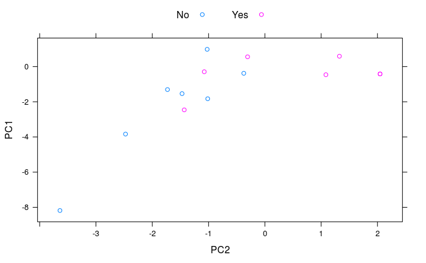

```r
prepro <- preProcess(emails.train, method="pca", pcaComp=2)
train.pca <- predict(prepro, emails.train)
test.pca <- predict(prepro, emails.test)
xyplot(PC1 ~ PC2,
       data = test.pca,
       groups = is.user,
       auto.key = list(columns = 2))
```

Fit a logistic regression model.

```r
lr.model <- glm(is.user ~.,family=binomial(link='logit'), data=train)
lr.model
```

```
Call:  glm(formula = is.user ~ ., family = binomial(link = "logit"),
    data = train)

Coefficients:
    (Intercept)       word.count  avg.word.length        num.lines        sentiment   num.recipients
         1.5042           1.2919           0.2554          -0.9185           0.6488           4.8535
   p.punct.char     p.alpha.char   p.numeric.char             wday             hour
         0.0801          -0.1482          -0.6520          -0.1662           1.0251

Degrees of Freedom: 57 Total (i.e. Null);  47 Residual
Null Deviance:      80.41
Residual Deviance: 54.16    AIC: 76.16
```

Fit a basic random forest model

```r
rf.model <- train(is.user ~ ., method='rf', data=train)
rf.model
```

```
Random Forest

58 samples
10 predictors
 2 classes: 'No', 'Yes'

No pre-processing
Resampling: Bootstrapped (25 reps)
Summary of sample sizes: 58, 58, 58, 58, 58, 58, ...
Resampling results across tuning parameters:

  mtry  Accuracy   Kappa
   2    0.7359441  0.4761846
   6    0.7215739  0.4502564
  10    0.7117369  0.4298534

Accuracy was used to select the optimal model using the largest value.
The final value used for the model was mtry = 2.
```

Train a gradient boosting machine (GBM) with 10-folder cross-validation over 10 resamplings. Reset the seed so results are consistent. See [Caret Reference](http://topepo.github.io/caret/model-training-and-tuning.html). GBMs report [good results for two classes](http://fastml.com/what-is-better-gradient-boosted-trees-or-random-forest/) but require more tuning than random forests. Parallelize across 14 of my 16 CPU Cores and search for optimal parameter settings

```r
require(doMC)
registerDoMC(cores = 14)
fitControl <- trainControl(method = "repeatedcv",
                           number = 10,
                           repeats = 10,
                           allowParallel=TRUE)
gbmGrid <-  expand.grid(interaction.depth = c(5, 7, 10),
                        n.trees = (1:3)*50,
                        shrinkage = c(0.5, 0.1),
                        n.minobsinnode = c(5,10, 15))
set.seed(2531)
gbm.model <- train(is.user ~ ., data = train,
                   method = "gbm",
                   trControl = fitControl,
                   verbose = FALSE,
                   tuneGrid = gbmGrid)
```

[output not shown]

[output cut: 1146 more lines]

[output not shown]

```r
gbm.model
```

```
Stochastic Gradient Boosting

58 samples
10 predictors
 2 classes: 'No', 'Yes'

No pre-processing
Resampling: Cross-Validated (10 fold, repeated 10 times)
Summary of sample sizes: 52, 52, 54, 52, 52, 52, ...
Resampling results across tuning parameters:

  shrinkage  interaction.depth  n.minobsinnode  n.trees  Accuracy   Kappa
  0.1         5                  5               50      0.7500000  0.5003047
  0.1         5                  5              100      0.7456667  0.4931285
  0.1         5                  5              150      0.7486667  0.4959341
  0.1         5                 10               50      0.7630000  0.5228904
  0.1         5                 10              100      0.7681667  0.5333233
  0.1         5                 10              150      0.7958333  0.5896870
  0.1         5                 15               50            NaN        NaN
  0.1         5                 15              100            NaN        NaN
  0.1         5                 15              150            NaN        NaN
  0.1         7                  5               50      0.7428333  0.4812604
  0.1         7                  5              100      0.7490000  0.4965984
  0.1         7                  5              150      0.7476667  0.4928105
  0.1         7                 10               50      0.7641667  0.5268798
  0.1         7                 10              100      0.7715000  0.5441292
  0.1         7                 10              150      0.8040000  0.6089677
  0.1         7                 15               50            NaN        NaN
  0.1         7                 15              100            NaN        NaN
  0.1         7                 15              150            NaN        NaN
  0.1        10                  5               50      0.7538333  0.5078838
  0.1        10                  5              100      0.7461667  0.4908758
  0.1        10                  5              150      0.7478333  0.4950599
  0.1        10                 10               50      0.7563333  0.5111588
  0.1        10                 10              100      0.7816667  0.5610306
  0.1        10                 10              150      0.7873333  0.5726973
  0.1        10                 15               50            NaN        NaN
  0.1        10                 15              100            NaN        NaN
  0.1        10                 15              150            NaN        NaN
  0.5         5                  5               50      0.7293333  0.4562721
```

[output cut: 15 more lines]

```
  0.5         7                 15              100            NaN        NaN
  0.5         7                 15              150            NaN        NaN
  0.5        10                  5               50      0.7486667  0.4968798
  0.5        10                  5              100      0.7593333  0.5179054
  0.5        10                  5              150      0.7560000  0.5107259
  0.5        10                 10               50      0.8020000  0.6036647
  0.5        10                 10              100      0.8136667  0.6276973
  0.5        10                 10              150      0.8146667  0.6280569
  0.5        10                 15               50            NaN        NaN
  0.5        10                 15              100            NaN        NaN
  0.5        10                 15              150            NaN        NaN

Accuracy was used to select the optimal model using the largest value.
The final values used for the model were n.trees = 150, interaction.depth = 10, shrinkage = 0.5 and
 n.minobsinnode = 10.
```

```r
trellis.par.set(caretTheme())
```

```
Note: The default device has been opened to honour attempt to modify trellis settings
```

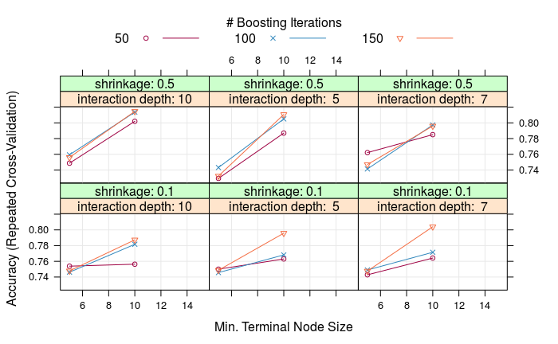

```r
plot(gbm.model)
```

# Variable Importance

If this is any indication, the percentages of characters distinguish these people. We see for example that sentiment and day of the week probably isn’t important. The percentage of different types of characters, time of day, etc., is important.

```r
varImp(rf.model)
```

```
rf variable importance

                Overall
hour            100.000
word.count       67.366
p.alpha.char     54.637
p.punct.char     48.678
num.lines        45.820
avg.word.length  44.511
p.numeric.char   42.754
num.recipients   22.421
wday              3.813
sentiment         0.000
```

```r
# varImp(gbm.model)
```

# Model Accuracy

```r
cat("Results on test set for Logistic Regression model:\n")
```

```
Results on test set for Logistic Regression model:
```

```r
lr.predict <- predict(lr.model, test)
lr.predict1 <- ifelse(lr.predict > 0.5,'Yes','No')
c(Accuracy=mean(lr.predict1==test$is.user))
```

```
 Accuracy
0.4285714
```

```r
cat("Results on test set for Random Forest model:\n")
```

```
Results on test set for Random Forest model:
```

```r
rf.predict <- predict(rf.model, test)
postResample(pred = rf.predict, obs = test$is.user)
```

```
 Accuracy     Kappa
0.8571429 0.7142857
```

```r
cat("Results on test set for Gradient Boosted model:\n")
```

```
Results on test set for Gradient Boosted model:
```

```r
gbm.predict <- predict(gbm.model, test)
postResample(pred = gbm.predict, obs = test$is.user)
```

```
 Accuracy     Kappa
0.5714286 0.1428571
```

Let’s take a deeper look at the accuracy of the Random Forest.

```r
confusionMatrix(data = rf.predict, reference = test$is.user, mode = "prec_recall")
```

```
Confusion Matrix and Statistics

          Reference
Prediction No Yes
       No   7   2
       Yes  0   5

               Accuracy : 0.8571
                 95% CI : (0.5719, 0.9822)
    No Information Rate : 0.5
    P-Value [Acc > NIR] : 0.00647

                  Kappa : 0.7143
 Mcnemar's Test P-Value : 0.47950

              Precision : 0.7778
                 Recall : 1.0000
                     F1 : 0.8750
             Prevalence : 0.5000
         Detection Rate : 0.5000
   Detection Prevalence : 0.6429
      Balanced Accuracy : 0.8571

       'Positive' Class : No
```